# IODS course project

## Bonus

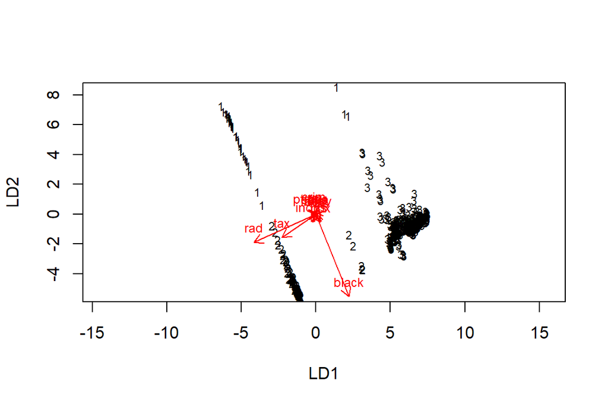

```r
library(MASS)
library(ggplot2)

set.seed(123)

# load and scale data
data("Boston")
boston_scaled <- scale(Boston)
boston_scaled <- as.data.frame(boston_scaled)

# perform k-means with 3 clusters. add cluster as a new column
km <- kmeans(Boston, centers = 3)
boston_scaled$cluster <- km$cluster

# the function for lda biplot arrows
lda.arrows <- function(x, myscale = 1, arrow_heads = 0.1, color = "red", tex = 0.75, choices = c(1,2)){
  heads <- coef(x)
  arrows(x0 = 0, y0 = 0,
         x1 = myscale * heads[,choices[1]],
         y1 = myscale * heads[,choices[2]], col=color, length = arrow_heads)
  text(myscale * heads[,choices], labels = row.names(heads),
       cex = tex, col=color, pos=3)
}

# fit the model and plot
lda.fit = lda(cluster ~ ., data=boston_scaled)
plot(lda.fit, dimen = 2)
lda.arrows(lda.fit, myscale = 2)
```

Vectors rad, tax and black are clearly visible and the are strongest determinants in dividing variables in different clusters. Vectors rad ja tax point almost to the same direction which means that they don’t have independent prediction power but as seen earlier they are correlated they might work in combination. Vector black goes to another direction, so it seems it is independent of the others.